# Point estimates comparison for the simplified Naomi model

Adam Howes

Abstract

**Background** We have run the simplified Naomi model using a range of inference methods: `TMB`, `aghq`, and `tmbstan`.

**Task** In this report, we compare the accuracy of the posterior distributions obtained from these inference methods using point estimates.

# 1 Background

We compare the inference results from `TMB`, `aghq`, and `tmbstan`. Import these inference results as follows:

```r
tmb <- readRDS("depends/tmb.rds")
aghq <- readRDS("depends/aghq.rds")
tmbstan <- readRDS("depends/tmbstan.rds")
```

# 2 Data manipulation

We’re interested in the latent field and certain model outputs (prevalence, incidence and treatment coverage):

```r
latent_pars <- unique(names(tmb$fit$par.full))[!(unique(names(tmb$fit$par.full)) %in% names(tmb$fit$par))]
output_pars <- c("rho_t1_out", "lambda_t1_out", "alpha_t1_out")

type_key <- data.frame(
  par = c(latent_pars, output_pars),
  type = c(rep("latent", times = length(latent_pars)), rep("output", times = length(output_pars)))
)
```

Extract the mean and standard deviation for each parameter for each inference method, then bind them together:

```r
df_tmb <- lapply(tmb$fit$sample[type_key$par], function(row) {
  data.frame("mean" = rowMeans(row), "sd" = matrixStats::rowSds(row)) %>%
    tibble::rowid_to_column("id")
  }) %>%
  dplyr::bind_rows(.id = "par") %>%
  mutate(method = "TMB")

df_aghq <- lapply(aghq$quad$sample[type_key$par], function(row) {
  data.frame("mean" = rowMeans(row), "sd" = matrixStats::rowSds(row)) %>%
    tibble::rowid_to_column("id")
  }) %>%
  dplyr::bind_rows(.id = "par") %>%
  mutate(method = "PCA-AGHQ")

df_tmbstan <- lapply(tmbstan$mcmc$sample[type_key$par], function(row) {
  data.frame("mean" = rowMeans(row), "sd" = matrixStats::rowSds(row)) %>%
    tibble::rowid_to_column("id")
  }) %>%
  dplyr::bind_rows(.id = "par") %>%
  mutate(method = "NUTS")

df <- bind_rows(df_tmb, df_aghq, df_tmbstan) %>%
  left_join(
    type_key,
    by = "par"
  )

head(df)
```

|  | par | id | mean | sd | method | type |
| --- | --- | --- | --- | --- | --- | --- |
| 1 | beta_rho | 1 | -2.91116095 | 1.4284992 | TMB | latent |
| 2 | beta_rho | 2 | 0.39998626 | 0.7082328 | TMB | latent |
| 3 | beta_alpha | 1 | 0.47532493 | 0.9449567 | TMB | latent |
| 4 | beta_alpha | 2 | 0.31456592 | 0.6507355 | TMB | latent |
| 5 | beta_lambda | 1 | -0.11272045 | 0.3719905 | TMB | latent |
| 6 | beta_lambda | 2 | 0.08043145 | 0.4443176 | TMB | latent |

Pivot so that the data is ready to plot:

```r
df_plot <- df %>%
  pivot_longer(cols = c("sd", "mean"), names_to = "indicator", values_to = "estimate") %>%
  pivot_wider(values_from = "estimate", names_from = "method") %>%
  pivot_longer(cols = c("TMB", "PCA-AGHQ"), names_to = "method", values_to = "approximate") %>%
  rename("truth" = "NUTS") %>%
  mutate(
    indicator = fct_recode(indicator, "Posterior mean estimate" = "mean", "Posterior SD estimate" = "sd"),
    method = fct_relevel(method, "TMB", "PCA-AGHQ")
  )

head(df_plot)
```

| par | id | type | indicator | truth | method | approximate |
| --- | --- | --- | --- | --- | --- | --- |
| beta_rho | 1 | latent | Posterior SD estimate | 1.864978 | TMB | 1.4284992 |
| beta_rho | 1 | latent | Posterior SD estimate | 1.864978 | PCA-AGHQ | 1.9800898 |
| beta_rho | 1 | latent | Posterior mean estimate | -2.655178 | TMB | -2.9111609 |
| beta_rho | 1 | latent | Posterior mean estimate | -2.655178 | PCA-AGHQ | -2.8394491 |
| beta_rho | 2 | latent | Posterior SD estimate | 1.105466 | TMB | 0.7082328 |
| beta_rho | 2 | latent | Posterior SD estimate | 1.105466 | PCA-AGHQ | 1.2616586 |

Calculate the root mean square and mean absolute errors between the approximate methods and NUTS (taken to be the truth):

```r
df_metrics <- df_plot %>%
  group_by(method, indicator, type) %>%
  summarise(
    rmse = sqrt(mean((truth - approximate)^2)),
    mae = mean(abs(truth - approximate))
  ) %>%
  ungroup()
head(df_metrics)
```

| method | indicator | type | rmse | mae |
| --- | --- | --- | --- | --- |
| TMB | Posterior mean estimate | latent | 0.078234956 | 0.0482717701 |
| TMB | Posterior mean estimate | output | 0.004703064 | 0.0024290349 |
| TMB | Posterior SD estimate | latent | 0.141128589 | 0.0713369823 |
| TMB | Posterior SD estimate | output | 0.001862580 | 0.0009079074 |
| PCA-AGHQ | Posterior mean estimate | latent | 0.062806260 | 0.0412627236 |
| PCA-AGHQ | Posterior mean estimate | output | 0.003701906 | 0.0021179382 |

Add difference in metric between TMB and PCA-AGHQ:

```r
df_metrics_pct <- df_metrics %>%
  split(~ indicator + type) %>%
  lapply(function(x) {
    x %>% summarise(
      rmse_diff = 100 * diff(rmse) / max(rmse),
      mae_diff = 100 * diff(mae) / max(mae)
    )
  }) %>%
  bind_rows(.id = "id") %>%
  separate(id, c("indicator", "type"), sep = "\\.")

#' Add as a naming column for plot
df_metrics <- df_metrics %>%
  left_join(
    df_metrics_pct,
    by = c("indicator", "type")
  ) %>%
  mutate(
    label = ifelse(
      method == "PCA-AGHQ",
      paste0("RMSE: ", signif(rmse, 2), " (", signif(rmse_diff, 2), "%)", "\nMAE: ", signif(mae, 2), " (", signif(mae_diff, 2), "%)"),
      paste0("RMSE: ", signif(rmse, 2), "\nMAE: ", signif(mae, 2))
    )
  )

write_csv(df_metrics, "mean-sd.csv")
```

# 3 Plots

## 3.1 Latent field

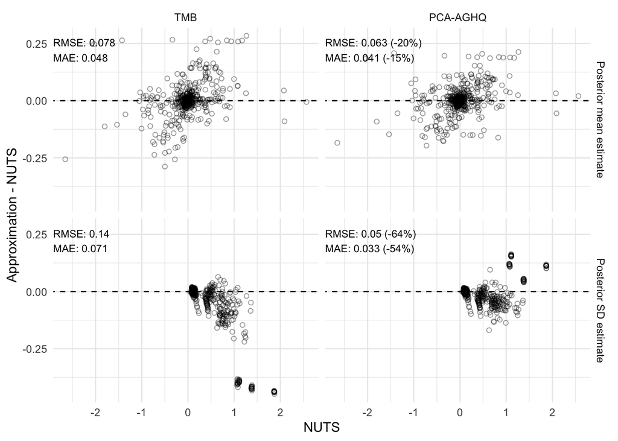

```r
df_plot_latent <- filter(df_plot, type == "latent")
df_metrics_latent <- filter(df_metrics, type == "latent")

df_plot_latent %>%
  ggplot(aes(x = truth, y = approximate - truth)) +
  geom_point(shape = 1, alpha = 0.4) +
  facet_grid(indicator ~ method) +
  geom_abline(slope = 0, intercept = 0, linetype = "dashed") +
  geom_text(data = df_metrics_latent, aes(x = -Inf, y = Inf, label = label), size = 3, hjust = 0, vjust = 1.5) +
  labs(x = "NUTS", y = "Approximation - NUTS") +
  theme_minimal()
```

```r
ggsave("mean-sd-latent.png", h = 6, w = 6.25)
```

Version split into two for presentations

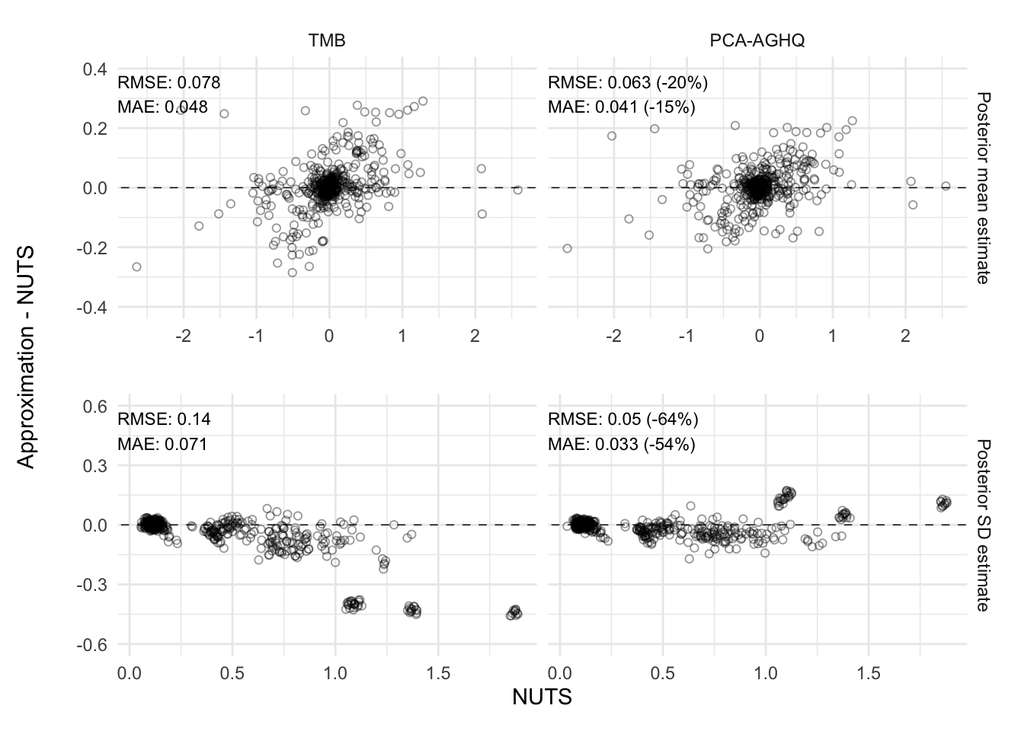

```r
jitter_amount <- 0.02

mean_plot_latent <- df_plot_latent %>%
  filter(indicator == "Posterior mean estimate") %>%
  ggplot(aes(x = truth, y = approximate - truth)) +
  geom_jitter(shape = 1, alpha = 0.4, width = jitter_amount, height = jitter_amount) +
  lims(y = c(-0.4, 0.4)) +
  facet_grid(indicator ~ method) +
  geom_abline(slope = 0, intercept = 0, linetype = "dashed", size = 0.25) +
  geom_text(
    data = filter(df_metrics_latent, indicator == "Posterior mean estimate"),
    aes(x = -Inf, y = Inf, label = label), size = 3, hjust = 0, vjust = 1.5
  ) +
  labs(x = "NUTS", y = "Approximation - NUTS") +
  theme_minimal()

ggsave("mean-latent.png", mean_plot_latent, h = 4, w = 6.25)

sd_plot_latent <- df_plot_latent %>%
  filter(indicator == "Posterior SD estimate") %>%
  ggplot(aes(x = truth, y = approximate - truth)) +
  geom_jitter(shape = 1, alpha = 0.4, width = jitter_amount, height = jitter_amount) +
  lims(y = c(-0.6, 0.6)) +
  facet_grid(indicator ~ method) +
  geom_abline(slope = 0, intercept = 0, linetype = "dashed", size = 0.25) +
  geom_text(
    data = filter(df_metrics_latent, indicator == "Posterior SD estimate"),
    aes(x = -Inf, y = Inf, label = label), size = 3, hjust = 0, vjust = 1.5
  ) +
  labs(x = "NUTS", y = "Approximation - NUTS") +
  theme_minimal()

ggsave("sd-latent.png", sd_plot_latent, h = 4, w = 6.25)

sd_plot_latent_alt <- sd_plot_latent +
  theme(
    strip.background = element_blank(),
    strip.text.x = element_blank()
  )

y_axis <- ggplot(data.frame(l = mean_plot_latent$labels$y, x = 1, y = 1)) +
  geom_text(aes(x, y, label = l), angle = 90) +
  theme_void() +
  coord_cartesian(clip = "off")

mean_plot_latent_alt <- mean_plot_latent
mean_plot_latent_alt$labels$x <- ""
mean_plot_latent_alt$labels$y <- sd_plot_latent_alt$labels$y <- ""

(mean_sd_plot_latent_alt <- y_axis + (mean_plot_latent_alt / sd_plot_latent_alt) +
  plot_layout(widths = c(1, 30)))
```

```r
ggsave("mean-sd-alt-latent.png", mean_sd_plot_latent_alt, h = 6, w = 6.25)
```

Where are the greatest errors occurring for the mean?

```r
df_plot_latent %>%
  filter(indicator == "Posterior mean estimate") %>%
  mutate(diff = abs(approximate - truth)) %>%
  arrange(desc(diff)) %>%
  select(indicator, par, id, method, truth, approximate, diff) %>%
  DT::datatable()
```

|  | indicator | par | id | method | truth | approximate | diff |
| --- | --- | --- | --- | --- | --- | --- | --- |
| 1 | Posterior mean estimate | us_alpha_xs | 32 | TMB | -0.498964189883565 | -0.786840601463531 | 0.287876411579966 |
| 2 | Posterior mean estimate | us_alpha_x | 21 | TMB | 1.26625916432786 | 1.54990162264754 | 0.283642458319676 |
| 3 | Posterior mean estimate | u_rho_a | 10 | TMB | 0.480822249366353 | 0.751918330862303 | 0.271096081495951 |
| 4 | Posterior mean estimate | u_rho_a | 3 | TMB | -0.335600404075248 | -0.0689401370497756 | 0.266660267025473 |
| 5 | Posterior mean estimate | u_rho_a | 2 | TMB | -1.42668836862854 | -1.1628675864193 | 0.263820782209236 |
| 6 | Posterior mean estimate | u_rho_a | 9 | TMB | 0.843357568072275 | 1.10683208202759 | 0.263474513955317 |
| 7 | Posterior mean estimate | u_rho_a | 7 | TMB | 1.17277905348973 | 1.43564274183112 | 0.262863688341396 |
| 8 | Posterior mean estimate | u_rho_a | 6 | TMB | 0.936372099426711 | 1.19576959946476 | 0.259397500038053 |
| 9 | Posterior mean estimate | u_rho_a | 4 | TMB | 0.372853762869554 | 0.631882361317571 | 0.259028598448017 |
| 10 | Posterior mean estimate | u_rho_a | 8 | TMB | 1.08536650295372 | 1.34400286973445 | 0.258636366780727 |

[output cut: 924 more lines]

What about for the standard deviations?

```r
df_plot_latent %>%
  filter(indicator == "Posterior SD estimate") %>%
  mutate(diff = abs(approximate - truth)) %>%
  arrange(desc(diff)) %>%
  select(indicator, par, id, method, truth, approximate, diff) %>%
  DT::datatable()
```

|  | indicator | par | id | method | truth | approximate | diff |
| --- | --- | --- | --- | --- | --- | --- | --- |
| 1 | Posterior SD estimate | u_rho_a | 2 | TMB | 1.87215572451782 | 1.42398532587872 | 0.448170398639103 |
| 2 | Posterior SD estimate | u_rho_a | 8 | TMB | 1.86843342292385 | 1.42660174175703 | 0.441831681166821 |
| 3 | Posterior SD estimate | u_rho_a | 10 | TMB | 1.86547356704759 | 1.42601565963354 | 0.43945790741405 |
| 4 | Posterior SD estimate | u_rho_a | 7 | TMB | 1.86580720715798 | 1.42673666211308 | 0.4390705450449 |
| 5 | Posterior SD estimate | u_rho_a | 6 | TMB | 1.86616704040978 | 1.4272157564676 | 0.438951283942172 |
| 6 | Posterior SD estimate | u_rho_a | 5 | TMB | 1.86703735762896 | 1.42925701836974 | 0.437780339259215 |
| 7 | Posterior SD estimate | u_rho_a | 3 | TMB | 1.86444325589435 | 1.42707694658431 | 0.437366309310037 |
| 8 | Posterior SD estimate | u_rho_a | 1 | TMB | 1.86787271987571 | 1.43070116199877 | 0.437171557876936 |
| 9 | Posterior SD estimate | beta_rho | 1 | TMB | 1.86497815432531 | 1.42849919430816 | 0.436478960017149 |
| 10 | Posterior SD estimate | u_rho_a | 9 | TMB | 1.86896649407637 | 1.43382439777729 | 0.435142096299081 |

[output cut: 924 more lines]

## 3.2 Outputs

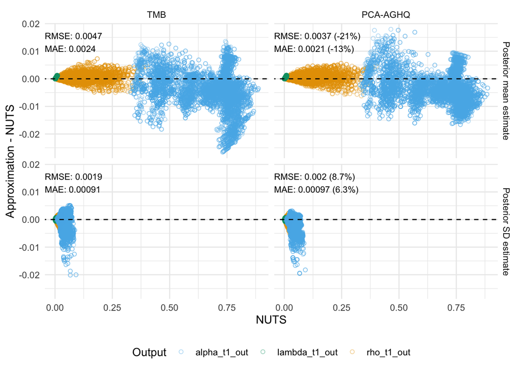

```r
df_plot_output <- filter(df_plot, type == "output")
df_metrics_output <- filter(df_metrics, type == "output")
cbpalette <- c("#56B4E9","#009E73", "#E69F00", "#F0E442", "#0072B2", "#D55E00", "#CC79A7", "#999999")

df_plot_output %>%
  ggplot() +
  geom_point(aes(x = truth, y = approximate - truth, color = par), shape = 1, alpha = 0.4) +
  scale_color_manual(values = cbpalette) +
  facet_grid(indicator ~ method) +
  geom_abline(slope = 0, intercept = 0, linetype = "dashed") +
  geom_text(data = df_metrics_output, aes(x = -Inf, y = Inf, label = label), size = 3, hjust = 0, vjust = 1.5) +
  labs(x = "NUTS", y = "Approximation - NUTS", col = "Output") +
  theme_minimal() +
  theme(legend.position = "bottom")
```

```r
ggsave("mean-sd-output.png", h = 6, w = 6.25)
```

Version split into two for presentations

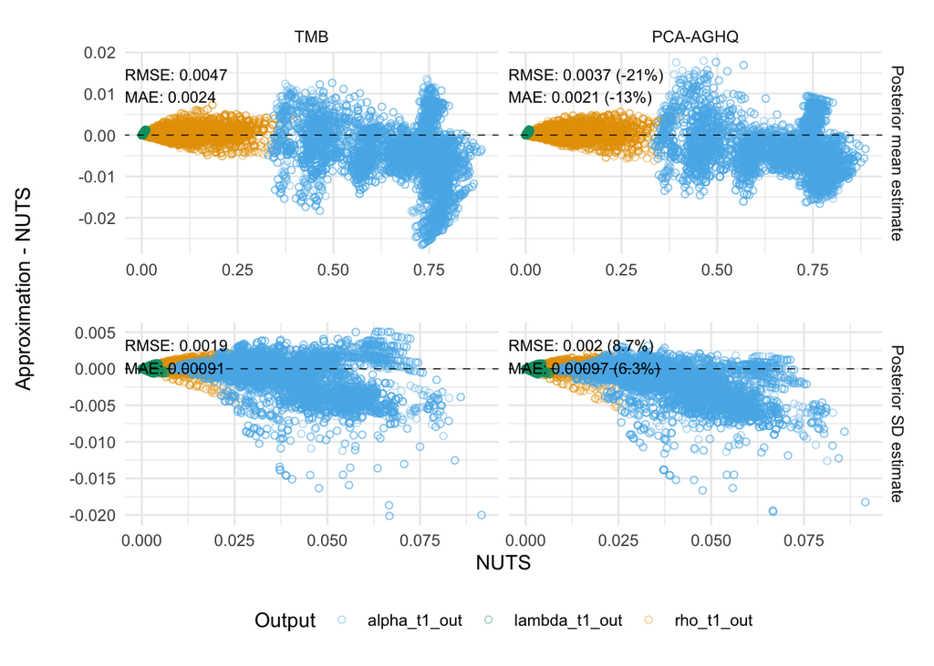

```r
jitter_amount <- 0

mean_plot_output <- df_plot_output %>%
  filter(indicator == "Posterior mean estimate") %>%
  ggplot() +
  geom_jitter(aes(x = truth, y = approximate - truth, color = par), shape = 1, alpha = 0.4, width = jitter_amount, height = jitter_amount) +
  scale_color_manual(values = cbpalette) +
  facet_grid(indicator ~ method) +
  geom_abline(slope = 0, intercept = 0, linetype = "dashed", size = 0.25) +
  geom_text(
    data = filter(df_metrics_output, indicator == "Posterior mean estimate"),
    aes(x = -Inf, y = Inf, label = label), size = 3, hjust = 0, vjust = 1.5
  ) +
  labs(x = "NUTS", y = "Approximation - NUTS", col = "Output") +
  theme_minimal()

ggsave("mean-output.png", mean_plot_output, h = 4, w = 6.25)

sd_plot_output <- df_plot_output %>%
  filter(indicator == "Posterior SD estimate") %>%
  ggplot() +
  geom_jitter(aes(x = truth, y = approximate - truth, color = par), shape = 1, alpha = 0.4, width = jitter_amount, height = jitter_amount) +
  scale_color_manual(values = cbpalette) +
  facet_grid(indicator ~ method) +
  geom_abline(slope = 0, intercept = 0, linetype = "dashed", size = 0.25) +
  geom_text(
    data = filter(df_metrics_output, indicator == "Posterior SD estimate"),
    aes(x = -Inf, y = Inf, label = label), size = 3, hjust = 0, vjust = 1.5
  ) +
  labs(x = "NUTS", y = "Approximation - NUTS", col = "Output") +
  theme_minimal()

ggsave("sd-output.png", sd_plot_output, h = 4, w = 6.25)

sd_plot_output_alt <- sd_plot_output +
  theme(
    strip.background = element_blank(),
    strip.text.x = element_blank(),
    legend.position = "bottom"
  )

y_axis <- ggplot(data.frame(l = mean_plot_output$labels$y, x = 1, y = 1)) +
  geom_text(aes(x, y, label = l), angle = 90) +
  theme_void() +
  coord_cartesian(clip = "off")

mean_plot_output_alt <- mean_plot_output +
  theme(legend.position = "none")

mean_plot_output_alt$labels$x <- ""
mean_plot_output_alt$labels$y <- sd_plot_output_alt$labels$y <- ""

(mean_sd_plot_output_alt <- y_axis + (mean_plot_output_alt / sd_plot_output_alt) +
  plot_layout(widths = c(1, 30)))
```

```r
ggsave("mean-sd-alt-output.png", mean_sd_plot_output_alt, h = 6, w = 6.25, bg = "white")
```